# Setting Up For MIGseq

This notebook will document the installations and other steps I used to set up both Treebeard and Khaleesi (plus my work computer for some cases) to analyze MIGseq data (Suyama et al. 2015).

# Install Stacks

```
#downloaded with curl from http://catchenlab.life.illinois.edu/stacks/source/stacks-2.4.tar.gz

tar xfvz stacks-2.4.tar.gz

# Based on running ./configure, Neither Khaleesi nor Treebeard have a high enough version of gcc. However, I figured out that they do, if you:

scl enable devtoolset-8 bash
gcc --version

#gcc (GCC) 8.2.1 20180905 (Red Hat 8.2.1-3)
#Copyright (C) 2018 Free Software Foundation, Inc.
#This is free software; see the source for copying conditions.  There is NO
#warranty; not even for MERCHANTABILITY or FITNESS FOR A PARTICULAR PURPOSE.
./configure #worked!

make -j 8 # use 8 threads to make

sudo make install # it all totally worked!
```

# Install Fastx-Toolkit

```
#Following these instructions:
#  http://hannonlab.cshl.edu/fastx_toolkit/install_centos.txt

# First install libgtextutils
wget https://github.com/agordon/libgtextutils/releases/download/0.7/libgtextutils-0.7.tar.gz

gunzip libgtextutils-0.7.tar.gz

tar -xf libgtextutils-0.7.tar

cd libgtextutils-0.7
./configure
make
sudo make install
cd ..



# Install fastx-toolkit

wget https://github.com/agordon/fastx_toolkit/releases/download/0.0.14/fastx_toolkit-0.0.14.tar.bz2

tar -xf fastx_toolkit-0.0.14.tarz.bz2

cd fastx_toolkit-0.0.14

./configure

#fails at this point. Found help here: http://hannonlab.cshl.edu/fastx_toolkit/pkg_config_email.txt
# It is not finding the gtextutils package that I installed above

export PKG_CONFIG_PATH=/usr/local/lib/pkgconfig:$PKG_CONFIG_PATH



make

sudo make install
```

# Install Tagdust

```
wget https://sourceforge.net/projects/tagdust/files/tagdust-2.33.tar.gz/download
gunzip download.tar.gz
tar -xvf download.tar
cd tagdust-2.33
./configure
make
sudo make install
```

# Sort sequences by species

I downloaded the sequences from Basespace and they are sitting in a folder on my work computer. I need to sort them into different folders by species

```
#!/bin/bash

find . -type f -name "pisoch*" -exec cp {} /Users/cran5048/Data/053119/pisoch \;

find . -type f -name "semcar*" -exec cp {} /Users/cran5048/Data/053119/semcar \;

find . -type f -name "tegfun*" -exec cp {} /Users/cran5048/Data/053119/tegfun \;

find . -type f -name "embjac*" -exec cp {} /Users/cran5048/Data/053119/embjac \;
```

# Copy them up to Khaleesi

```
scp -r pisoch/ khaleesi:/projects/crandall/pisoch

scp -r semcar/ khaleesi:/projects/crandall/semcar
scp -r tegfun/ khaleesi:/projects/crandall/tegfun
scp -r embjac/ khaleesi:/projects/crandall/embjac
```

# FastQC

Here are some images from pisoch_11-01 Read 2

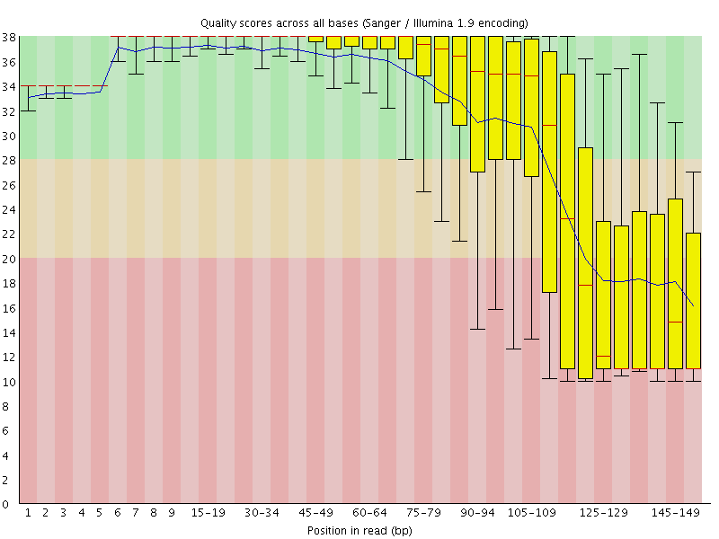

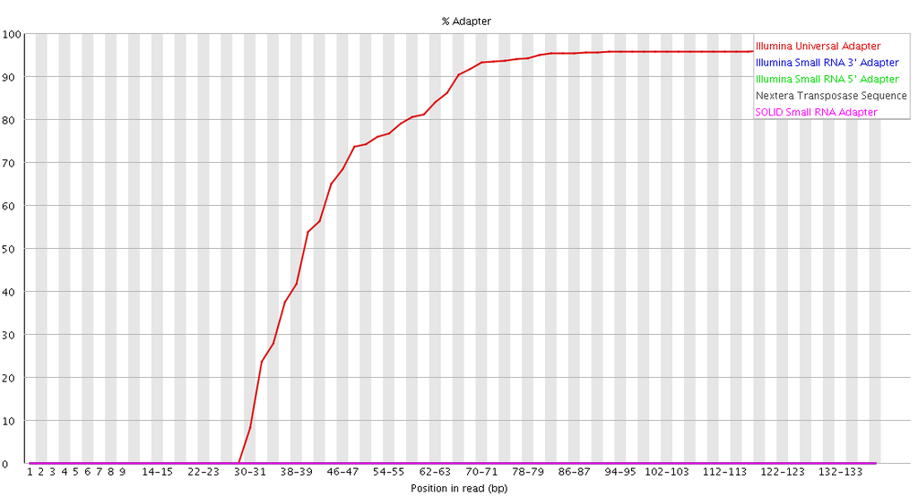

Adapter Content

And you can clearly see the microsatellite content at the beginning of the read:

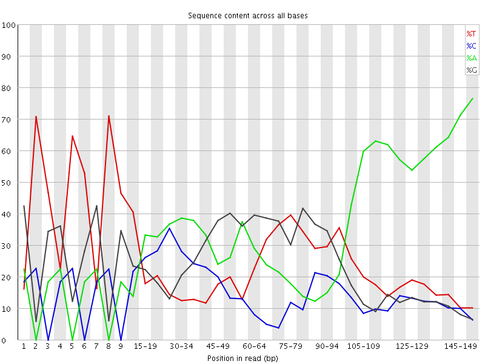

per base sequence content

# Trim the msat from read 2

Following Suyama et al. I use `fastx_trimmer` to trim off the first 14 bases from Read 2. - fastq_trim.sh, run from the top directory

```
#trim the first 14 bases (the msat + anchor sequences of PCR1 primers) from Read 2, and the last 46 bases to leave a fragment of 90bp
#trim 60 bases from the 3' end of read 1 to leave a fragment of 90bp
for i in *R2*.fastq

    do
        cat $i | fastx_trimmer -Q33 -f 15 -o temp.fastq
        cat temp.fastq | fastx_trimmer -Q33 -t 46 -o ../2trimmed/$(basename $i .fastq)_trim.fastq
    done

for i in *R1*.fastq
    do
        cat $i | fastx_trimmer -Q33 -t 60 -o ../2trimmed/$(basename $i .fastq)_trim.fastq
    done
```

# Quality filter

fastq_filter.sh

```
mkdir filter_logs

for i in *.fastq

    do
        cat $i | fastq_quality_filter -Q33 -q 30 -p 40 -o ../3filtered/$(basename $i .fastq)_filter.fastq > ./filter_logs/$(basename $i .fastq).txt
    done
```

# Trim the sequence primers

Need to trim the Read 2 sequencing primer from Read 1 and the Read 1 sequencing primer from Read 2.

seq_primer_trim.sh

```
#!/bin/bash

#tagdust command: -dust 100 is default, not sure what it is referring to.
# -1 R:N refers to a hidden markov model for a single read (as opposed to more complex architectures)
#!/bin/bash

for i in *R1*.fastq

    do
        tagdust -ref /projects/crandall/MIGseq/Read2Seq.txt -dust 100 -1 R:N $i  -o ../4dusted/$(basename $i .fastq)_dust
    done


for i in *R2*.fastq

    do
        tagdust -ref /projects/crandall/MIGseq/Read1Seq.txt -dust 100 -1 R:N $i -o ../4dusted/$(basename $i .fastq)_dust
    done
```

# Pipeline

A pipeline to roll all of this together and run on the other species. qc_pipeline.sh

```
#!/bin/bash

#create directory structure
mkdir 1original
mkdir 2trimmed
mkdir 3filtered
mkdir 4dusted
mkdir 5concatenated
mkdir 6preprocessed
mkdir 7stacks

#move everything into original
mv *.fastq ./1original

#Trim
echo "Running fastx_trimmer to remove 14 msat bases from read 2 and truncate all reads to 90bp"
cd 1original
../../fastq_trim.sh
cd ..

#Filter
echo "Running fastq_quality_filter to trim low quality bases and remove low quality reads"
cd 2trimmed
../../fastq_filter.sh
cd ..

#Tagdust - remove sequencing primers and poly A sequences
echo "Running Tagdust to remove sequencing primers and low complexity reads"
cd 3filtered
../../seq_primer_trim.sh
cd ..

# Concatenate the read 1 and read 2 together for each individual (as suggested by Suyama et al. 2015)
echo "Concatenate read 1 and read 2 and rename to just the sample name"
#rename to just the individual identifier for input into stacks
cd 4dusted
#move the extraneous files out of the way
mkdir tagdust_logs
mv *logfile* ./tagdust_logs
mkdir unextracted
mv *un.fq ./unextracted
#this for loop finds all read 1s, takes the sample name (delimited by -) and
#concatenates the two files with this prefix, placing the resulting file, named by the sample name, in the final directory
for filename in *R1*dust.fq
    do
      prefix=$(echo $filename | sed 's/^\([a-z]*-[0-9]*-[0-9]*\).*/\1/')
      echo "now concatenating $prefix"
      cat $prefix* > ../5concatenated/$prefix.fq
    done
cd ..

# remove sequences with Ns and zip them up
echo "Running process_shortreads to remove reads with N and zip final files"
process_shortreads -p ./5concatenated -o ./6preprocessed -c

cd ..
```

Code to restart pipeline

```
mv 1original/* ./
rm -r */
../qc_pipeline.sh
```

# Run Stacks

I am going to run the denovo pipeline using the parameters suggested by Suyama. The command line for that for Tegula funebralis looks like this:

```
[cran5048@khaleesi tegfun]$ denovo_map.pl --samples ./5final --popmap tegfun_popmap.txt -o ./6stacks -T 5 -M 2 -m 20 -n 4 -r 0.5 -X "ustacks: -d" -d
Parsed population map: 24 files in 2 populations and 1 group.
Found 24 sample file(s).

Indentifying unique stacks...
  /usr/local/bin/ustacks -t fastq -f ./5final/tegfun-19-01.fq -o ./6stacks -i 1 -m 20 -p 5 -M 2  -d
  /usr/local/bin/ustacks -t fastq -f ./5final/tegfun-19-02.fq -o ./6stacks -i 2 -m 20 -p 5 -M 2  -d
  /usr/local/bin/ustacks -t fastq -f ./5final/tegfun-19-03.fq -o ./6stacks -i 3 -m 20 -p 5 -M 2  -d
  /usr/local/bin/ustacks -t fastq -f ./5final/tegfun-19-04.fq -o ./6stacks -i 4 -m 20 -p 5 -M 2  -d
  /usr/local/bin/ustacks -t fastq -f ./5final/tegfun-19-05.fq -o ./6stacks -i 5 -m 20 -p 5 -M 2  -d
  /usr/local/bin/ustacks -t fastq -f ./5final/tegfun-19-06.fq -o ./6stacks -i 6 -m 20 -p 5 -M 2  -d
  /usr/local/bin/ustacks -t fastq -f ./5final/tegfun-19-07.fq -o ./6stacks -i 7 -m 20 -p 5 -M 2  -d
  /usr/local/bin/ustacks -t fastq -f ./5final/tegfun-19-08.fq -o ./6stacks -i 8 -m 20 -p 5 -M 2  -d
  /usr/local/bin/ustacks -t fastq -f ./5final/tegfun-19-09.fq -o ./6stacks -i 9 -m 20 -p 5 -M 2  -d
  /usr/local/bin/ustacks -t fastq -f ./5final/tegfun-19-10.fq -o ./6stacks -i 10 -m 20 -p 5 -M 2  -d
  /usr/local/bin/ustacks -t fastq -f ./5final/tegfun-19-11.fq -o ./6stacks -i 11 -m 20 -p 5 -M 2  -d
  /usr/local/bin/ustacks -t fastq -f ./5final/tegfun-19-12.fq -o ./6stacks -i 12 -m 20 -p 5 -M 2  -d
  /usr/local/bin/ustacks -t fastq -f ./5final/tegfun-83-01.fq -o ./6stacks -i 13 -m 20 -p 5 -M 2  -d
  /usr/local/bin/ustacks -t fastq -f ./5final/tegfun-83-02.fq -o ./6stacks -i 14 -m 20 -p 5 -M 2  -d
  /usr/local/bin/ustacks -t fastq -f ./5final/tegfun-83-03.fq -o ./6stacks -i 15 -m 20 -p 5 -M 2  -d
  /usr/local/bin/ustacks -t fastq -f ./5final/tegfun-83-04.fq -o ./6stacks -i 16 -m 20 -p 5 -M 2  -d
  /usr/local/bin/ustacks -t fastq -f ./5final/tegfun-83-05.fq -o ./6stacks -i 17 -m 20 -p 5 -M 2  -d
  /usr/local/bin/ustacks -t fastq -f ./5final/tegfun-83-06.fq -o ./6stacks -i 18 -m 20 -p 5 -M 2  -d
  /usr/local/bin/ustacks -t fastq -f ./5final/tegfun-83-07.fq -o ./6stacks -i 19 -m 20 -p 5 -M 2  -d
  /usr/local/bin/ustacks -t fastq -f ./5final/tegfun-83-08.fq -o ./6stacks -i 20 -m 20 -p 5 -M 2  -d
  /usr/local/bin/ustacks -t fastq -f ./5final/tegfun-83-09.fq -o ./6stacks -i 21 -m 20 -p 5 -M 2  -d
  /usr/local/bin/ustacks -t fastq -f ./5final/tegfun-83-10.fq -o ./6stacks -i 22 -m 20 -p 5 -M 2  -d
  /usr/local/bin/ustacks -t fastq -f ./5final/tegfun-83-11.fq -o ./6stacks -i 23 -m 20 -p 5 -M 2  -d
  /usr/local/bin/ustacks -t fastq -f ./5final/tegfun-83-12.fq -o ./6stacks -i 24 -m 20 -p 5 -M 2  -d

Depths of Coverage for Processed Samples:

Generating catalog...
  /usr/local/bin/cstacks -P ./6stacks -M tegfun_popmap.txt -p 5 -n 4

Matching samples to the catalog...
  /usr/local/bin/sstacks -P ./6stacks -M tegfun_popmap.txt -p 5

Sorting reads by RAD locus...
  /usr/local/bin/tsv2bam -P ./6stacks  -M tegfun_popmap.txt -t 5

Calling variants, genotypes and haplotypes...
  /usr/local/bin/gstacks -P ./6stacks -M tegfun_popmap.txt -t 5

Calculating population-level summary statistics
  /usr/local/bin/populations -P ./6stacks -M tegfun_popmap.txt -t 5 --min-samples-per-pop 0.5

denovo_map.pl is done.
```

Had to clean semcar data of Ns

```
process_shortreads -p ./5final -o ./5.5final -c
```

Rerun `populations` for each, calculating Fst

```
 populations -P ./ -t 5 -M ../tegfun_popmap.txt -p 2 -r 0.75 -H --hwe --fstats --fst_correction 'p_value' --fasta-loci --fasta-samples --fasta-samples-raw --genepop   --phylip-var --structure --vcf
```

# Convert to Migrate Format

I found this handy script on the [Migrate forum](https://groups.google.com/forum/#!topic/migrate-support/IPRpWtePwus).

When debugging I found that I needed to replace `nextline = newfasta.next` method with:

```python
nextline = next(newfasta, None)
if(nextline == None):
  break
nextline = nextline.strip()
```

I also had to remove all the sample names in brackets from the `populations.samples.fa` file using a regular expression search in bbedit. Also had to remove the top commented line.